# Tarea sobre los Temas 3 a 5

# 2 Pregunta 2

Cuando cierta empresa recibe una invitación para optar a un contrato, la oferta no se puede completar hasta que sea revisada por cuatro departamentos: Ingeniería, Personal, Legal y Contabilidad. Los departamentos empiezan a trabajar al mismo tiempo, pero lo hacen de forma independiente. El tiempo en semanas que emplean en completar la revisión es una variable aleatoria con las siguientes distribuciones:

- Ingeniería: Exponencial con media 3 semanas
- Personal: Normal con media 4 y desviación típica 1;
- Legal: 2 o 4 semanas, siendo ambos valores equiprobables
- Contabilidad: Uniforme continua en el intervalo (1,5).

Se trata de simular el tiempo W que tarda la empresa en preparar una oferta. Para ello se pueden implementar los siguientes pasos:

## 2.1 Fijar M (número de ofertas, se recomienda al menos 1000).

```r
M=1000 # número de ofertas
```

## 2.2 Definir una matriz Mx4 donde se irán almacenando los valores generados.

```r
matriz=matrix(NA,M,4) # Posteriormente almacenaremos los datos
dim(matriz)
```

```
## [1] 1000    4
```

## 2.3 Repetir M veces:

### 2.3.1 Generar de forma independiente los cuatro tiempos según las cuatro distribuciones.

```r
W = rep(NA,M)
for (i in 1:M) { # Guardar esos cuatro tiempos en una fila de la matriz
  vIng = rexp(1,1/3)
  VPer = rnorm(1,4,1)
  x=c(2,4)
  vLeg = sample(x,1,replace = T)
  vCon = runif(1,1,5)


# Para cada i genero un valor de W
  W[i] = max(vIng,VPer,vLeg,vCon) #Calcular W como el máximo de los cuatro tiempos.
}
# Al final tendrás una m.a.s. de valores W de tamaño M: W_1, ..., W_M
```

Creo la matriz

```r
m= matrix(W,ncol = 4)
colnames(m)<- c("Ingeniería","Personal","Legal","Contabilidad")
head(m)
```

```
##      Ingeniería Personal    Legal Contabilidad
## [1,]   5.616554 4.647691 4.036856     3.466744
## [2,]   4.000000 4.964782 4.388882     5.067620
## [3,]   4.000000 8.308340 5.922192     4.287492
## [4,]   3.283621 6.854786 4.000000     4.000000
## [5,]   7.461851 4.564207 4.000000     8.546088
## [6,]   4.169591 4.000000 3.476664     6.717074
```

Se pide:

- Estudiar gráficamente la distribución de la variable aleatoria W “tiempo que transcurre hasta completar la oferta”.

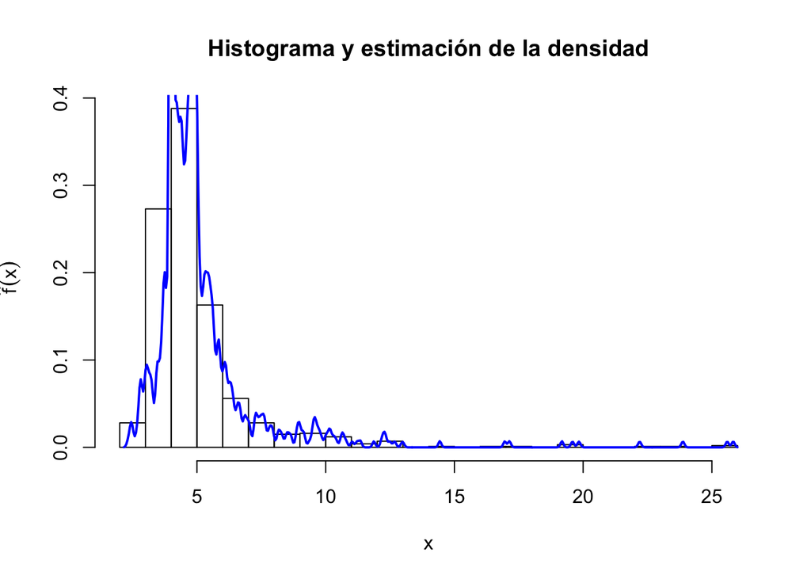

```r
hist(W,
     br=30,
     prob=TRUE,
     main="Histograma y estimación de la densidad",
     ylab=expression(hat(f)(x)),xlab="x")
lines(density(W,bw="SJ"),col="blue",lwd=2)
```

Estimar su media y su mediana.

```r
apply(X=m,FUN=median,MARGIN = 2) # Mediana por columnas
```

```
##   Ingeniería     Personal        Legal Contabilidad
##     4.499417     4.643564     4.509524     4.647242
```

```r
apply(X=m,FUN=mean,MARGIN = 2) # Media por columnas
```

```
##   Ingeniería     Personal        Legal Contabilidad
##     4.917359     5.039717     5.259651     5.094258
```

Para los datos totales, sin hacerlo por departamento:

Estimación del tiempo medio

```r
mean(W)
```

```
## [1] 5.077746
```

Estimación de la mediana:

```r
median(W)
```

```
## [1] 4.568647
```

### 2.3.2 Estimar la probabilidad de que W supere las 6 semanas.

$$P[W>6]$$

```r
ajuste<- logspline(m)
ajuste
```

```
##  knots A(1)/D(2)   loglik     AIC minimum penalty maximum penalty
##      7         2 -1513.31 3068.07           57.83             Inf
##      8         2 -1484.40 3017.15            3.33           57.83
##      9         2 -1483.82 3022.91              NA              NA
##     10         2 -1481.07 3024.31            2.59            3.33
##     11         2 -1479.89 3028.86              NA              NA
##     12         2 -1478.48 3032.95            0.92            2.59
##     13         2 -1478.21 3039.32              NA              NA
##     14         2 -1477.56 3044.92            0.05            0.92
##     15         2 -1477.54 3051.80              NA              NA
##     16         2 -1477.51 3058.63            0.00            0.05
##     17         1 -1477.51 3065.54            0.00            0.00
## the present optimal number of knots is  8
## penalty(AIC) was the default: BIC=log(samplesize): log( 1000 )= 6.91
```

Luego, la probabilidad será:

```r
1-plogspline(6, ajuste)
```

```
## [1] 0.1492821
```

### 2.3.3 ¿Cuál es el departamento que suele tardar más en completar la revisión?

```r
m %>%
  colSums()/M
```

```
##   Ingeniería     Personal        Legal Contabilidad
##     1.229340     1.259929     1.314913     1.273564
```

### 2.3.4 ¿Cuál es la ordenación más frecuente de los cuatro tiempos?

```r
library(modeest)
apply(X=m,FUN=mfv,MARGIN = 2)
```

```
##   Ingeniería     Personal        Legal Contabilidad
##            4            4            4            4
```

```r
mfv(W)
```

```
## [1] 4
```

# 3 Pregunta 3

Generar aleatoriamente un conjunto de datos donde tengo sentido construir un modelo de clasificación o de predicción. Ajustar el modelo y estimar su capacidad de generalización mediante Jackknife y mediante Validación Cruzada (K=10).

## 3.1 Generamos los datos con la función sample(aleatoriamente).

Generaremos un dataset con 120 filas y 3 variables, por ejemplo.

```r
V=c(rep("Z1",70),rep("Z2",50))
V1=runif(120,5,13)
V2=rnorm(120,80,25)
V3=rnorm(120,30,5)


dataSet=cbind.data.frame(V,V1,V2,V3)

head(dataSet)
```

```
##    V        V1        V2       V3
## 1 Z1  9.381650  64.08176 33.78758
## 2 Z1  5.074379  87.09544 29.28298
## 3 Z1  8.302148  80.39263 19.12421
## 4 Z1  7.507059 119.34714 26.41161
## 5 Z1  7.196900  69.17136 40.44607
## 6 Z1 10.346250  53.12056 27.02017
```

```r
summary(dataSet)
```

```
##   V            V1               V2               V3
##  Z1:70   Min.   : 5.074   Min.   : 17.64   Min.   :14.75
##  Z2:50   1st Qu.: 7.371   1st Qu.: 63.33   1st Qu.:26.27
##          Median : 9.387   Median : 77.87   Median :29.31
##          Mean   : 9.211   Mean   : 81.61   Mean   :29.32
##          3rd Qu.:11.504   3rd Qu.: 98.86   3rd Qu.:32.08
##          Max.   :12.971   Max.   :164.91   Max.   :46.71
```

```r
dataSet$V = as.factor(dataSet$V)
summary(dataSet)
```

```
##   V            V1               V2               V3
##  Z1:70   Min.   : 5.074   Min.   : 17.64   Min.   :14.75
##  Z2:50   1st Qu.: 7.371   1st Qu.: 63.33   1st Qu.:26.27
##          Median : 9.387   Median : 77.87   Median :29.31
##          Mean   : 9.211   Mean   : 81.61   Mean   :29.32
##          3rd Qu.:11.504   3rd Qu.: 98.86   3rd Qu.:32.08
##          Max.   :12.971   Max.   :164.91   Max.   :46.71
```

## 3.2 Modelo

Elegimos como variable respuesta la variable V

```r
modelo = glm(V~., data = dataSet, family = "binomial")
summary(modelo)
```

```
##
## Call:
## glm(formula = V ~ ., family = "binomial", data = dataSet)
##
## Deviance Residuals:
##     Min       1Q   Median       3Q      Max
## -1.6230  -1.0285  -0.7151   1.2017   1.6927
##
## Coefficients:
##              Estimate Std. Error z value Pr(>|z|)
## (Intercept) -4.382560   1.671615  -2.622  0.00875 **
## V1           0.003231   0.079063   0.041  0.96741
## V2           0.018543   0.007523   2.465  0.01370 *
## V3           0.084482   0.040840   2.069  0.03859 *
## ---
## Signif. codes:  0 '***' 0.001 '**' 0.01 '*' 0.05 '.' 0.1 ' ' 1
##
## (Dispersion parameter for binomial family taken to be 1)
##
##     Null deviance: 163.01  on 119  degrees of freedom
## Residual deviance: 153.19  on 116  degrees of freedom
## AIC: 161.19
##
## Number of Fisher Scoring iterations: 4
```

Intervalo de confianza para las estimaciones de las variables, al 95% de nivel de significación:

```r
confint(modelo)
```

```
##                    2.5 %      97.5 %
## (Intercept) -7.855232069 -1.25320692
## V1          -0.152283779  0.15934825
## V2           0.004288475  0.03398499
## V3           0.007156356  0.16855637
```

```r
exp(coef(modelo))
```

```
## (Intercept)          V1          V2          V3
##  0.01249334  1.00323581  1.01871565  1.08815301
```

## 3.3 Predicciones

```r
predicciones = predict.glm(modelo,newdata = dataSet)
head(predicciones)
```

```
##           1           2           3           4           5           6
## -0.30957001 -0.27730711 -1.24939798  0.08600644  0.34026798 -1.08142707
```

```r
probabilidad = exp(predicciones)/(1+exp(predicciones))
head(probabilidad)
```

```
##         1         2         3         4         5         6
## 0.4232197 0.4311141 0.2228044 0.5214884 0.5842556 0.2532361
```

Definimos las funciones:

```r
abinario=function(x)
{if (x>0.5) {return(1)}
  else{return(0)}
}
elfactor=function(x)
{if (x==0) {return(("Z1"))}
  if (x==1){return(("Z2"))}}
```

```r
estimacionbi=lapply(probabilidad,abinario)
estimacion= lapply(estimacionbi, elfactor)
```

Vamos a ver la tabla con las predicciones, donde podremos ver si nos hemos equivocado o no al predecir.

```r
Prediccion=t(as.data.frame(estimacion))
Tabla_Completa=cbind.data.frame(dataSet,Prediccion)
Tabla_Completa
```

```
##       V        V1        V2       V3 Prediccion
## X1   Z1  9.381650  64.08176 33.78758         Z1
## X2   Z1  5.074379  87.09544 29.28298         Z1
## X3   Z1  8.302148  80.39263 19.12421         Z1
## X4   Z1  7.507059 119.34714 26.41161         Z2
## X5   Z1  7.196900  69.17136 40.44607         Z2
## X6   Z1 10.346250  53.12056 27.02017         Z1
## X7   Z1 11.240119 157.69588 28.56563         Z2
## X8   Z1 12.062873  59.86759 31.58292         Z1
## X9   Z1 12.083823  65.33542 30.27070         Z1
## X10  Z1 12.251944  48.32718 36.44847         Z1
## X11  Z1 12.024831  75.39304 25.39136         Z1
## X12  Z1  5.081045  74.23401 21.50898         Z1
## X13  Z1  9.707377  50.71937 23.45266         Z1
## X14  Z1 11.695551 112.00965 34.43045         Z2
## X15  Z1  5.325572  68.56925 31.65741         Z1
## X16  Z1 10.771849  83.99959 25.31125         Z1
## X17  Z1  5.622309  56.32275 35.26916         Z1
## X18  Z1  7.969696  17.64319 22.77715         Z1
## X19  Z1  6.003522 132.54143 19.08592         Z1
## X20  Z1 12.857777  65.57201 27.41119         Z1
## X21  Z1  6.565024  73.18399 26.21096         Z1
## X22  Z1 12.049611  68.42075 24.98509         Z1
## X23  Z1 11.756419  66.31972 26.82167         Z1
## X24  Z1 12.211158  65.71618 27.44289         Z1
## X25  Z1  9.264168  78.65607 23.31932         Z1
## X26  Z1 10.200916  50.06152 26.66432         Z1
## X27  Z1 10.198909 127.71236 26.30247         Z2
## X28  Z1  6.757359 122.63579 24.83263         Z2
## X29  Z1  7.323213  61.95399 22.69338         Z1
## X30  Z1  6.655759  70.49231 20.13328         Z1
## X31  Z1  6.732737  58.83163 14.74855         Z1
## X32  Z1 12.353549  82.83279 26.58605         Z1
## X33  Z1  5.435342  78.80219 26.77190         Z1
## X34  Z1  7.741333  66.61479 28.99709         Z1
## X35  Z1 11.928241  45.45242 21.18657         Z1
## X36  Z1  8.793472 112.68877 30.62435         Z2
## X37  Z1  9.392629 110.73003 39.11108         Z2
## X38  Z1 11.957458  61.10520 30.77581         Z1
## X39  Z1 10.239902  93.66216 31.17653         Z2
```

[output cut: 66 more lines]

```
## X106 Z2  9.895663 107.83331 34.22997         Z2
## X107 Z2  9.419667  97.01903 23.79509         Z1
## X108 Z2 10.458218 116.21118 31.93842         Z2
## X109 Z2  5.767613  82.72722 46.71121         Z2
## X110 Z2 12.622099  78.56219 26.58087         Z1
## X111 Z2  5.679926  55.62370 31.18922         Z1
## X112 Z2  8.362764 127.39766 24.05052         Z2
## X113 Z2  7.066145 114.53680 30.45253         Z2
## X114 Z2  5.171291  94.72947 31.78246         Z2
## X115 Z2 12.931239  33.91321 30.20851         Z1
## X116 Z2 10.970312  60.92208 32.11810         Z1
## X117 Z2  5.771978  51.80201 33.74253         Z1
## X118 Z2 10.674353  71.50110 27.35044         Z1
## X119 Z2  8.118917  65.04542 32.60858         Z1
## X120 Z2  5.715604  62.03483 26.86249         Z1
```

```r
length(Tabla_Completa$V)
```

```
## [1] 120
```

```r
length(Tabla_Completa$Prediccion)
```

```
## [1] 120
```

```r
#si=length(which(Tabla_Completa$V==Tabla_Completa$Prediccion))
#si/nrow(Tabla_Completa)*100
```

## 3.4 Estimaciones JACKKNIFE

```r
n=nrow(dataSet)
prediccionJackknife = numeric(n)
probJack=numeric(n)
for(i in 1:n){
  modelo_i = glm(V~.,data=dataSet[-i,],family = "binomial")
  prJack<-predict.glm(modelo_i,newdata=dataSet[i,])
  probJack[i] = exp(prJack)/(1+exp(prJack))
  binJack= abinario(probJack[i])
  prediccionJackknife[i]=elfactor(binJack)
}

length(which(prediccionJackknife==dataSet$V))*100/n
```

```
## [1] 55
```

```r
length(which(prediccionJackknife==Tabla_Completa$Prediccion))*100/n
```

```
## [1] 93.33333
```

## 3.5 Validación cruzada

```r
library(caret)
modelocaret=train(V~.,data=dataSet, method="glm",
                  trControl = trainControl(method="CV",number=10))
modelocaret$results
```

```
##   parameter  Accuracy      Kappa AccuracySD   KappaSD
## 1      none 0.5583333 0.04927904  0.1523985 0.3283157
```

```r
modelocaret$results["Accuracy"]*100
```

```
##   Accuracy
## 1 55.83333
```

# 4 Pregunta 4

Bootstrap. Implementar una función que calcule el estadístico de Fisher de comparación de coeficientes de correlación lineal:

$$T = \dfrac{Z_1 - Z_2}{\sqrt{\frac{1}{n_1 - 3}+\frac{1}{n_2 - 3}}}$$

Donde:

- Z1 y Z2 representan la transformación de Fisher de los respectivos coeficientes de correlación lineal para dos grupos
- n1 y n2 son las frecuencias absolutas respectivas de los grupos.

Sobre un conjunto de datos apropiado (que puede ser generado), utilizando el anterior estadístico, realizar e interpretar un test bootstrap bilateral de comparación de los coeficientes de correlación lineal (B=1999).